# Practicing Machine Learning with Iris dataset

## Selecting the best model

We now have 5 models and accuracy estimations for each. We need to compare the models to each other and select the most accurate. We can report on the accuracy of each model by first creating a list of the created models and using the summary function.

```r
results <- resamples(list(lda=fit_lda, cart=fit_cart, knn=fit_knn, svm=fit_svm, rf=fit_rf))
summary(results)
```

```
##
## Call:
## summary.resamples(object = results)
##
## Models: lda, cart, knn, svm, rf
## Number of resamples: 10
##
## Accuracy
##           Min.   1st Qu.    Median      Mean 3rd Qu. Max. NA's
## lda  0.9333333 0.9500000 1.0000000 0.9800000       1    1    0
## cart 0.8666667 0.9333333 0.9333333 0.9466667       1    1    0
## knn  0.9333333 0.9500000 1.0000000 0.9800000       1    1    0
## svm  0.8666667 0.9500000 1.0000000 0.9666667       1    1    0
## rf   0.8666667 0.8833333 0.9666667 0.9466667       1    1    0
##
## Kappa
##      Min. 1st Qu. Median Mean 3rd Qu. Max. NA's
## lda   0.9   0.925   1.00 0.97       1    1    0
## cart  0.8   0.900   0.90 0.92       1    1    0
## knn   0.9   0.925   1.00 0.97       1    1    0
## svm   0.8   0.925   1.00 0.95       1    1    0
## rf    0.8   0.825   0.95 0.92       1    1    0
```

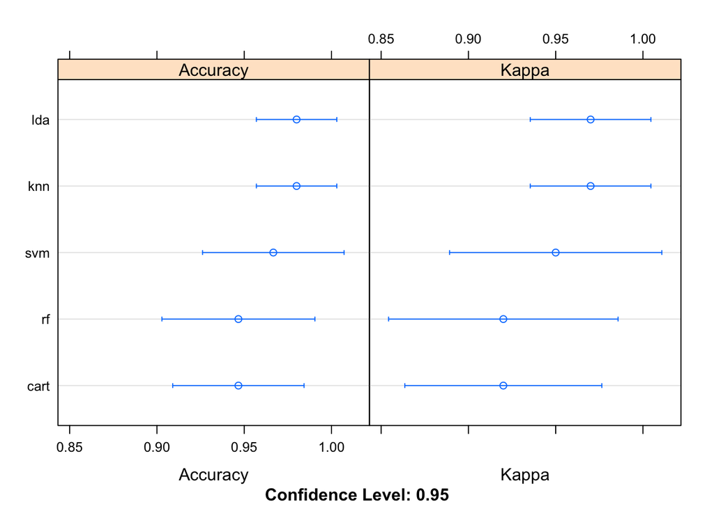

```r
# compare accuracy of models using a dotplot
dotplot(results)
```

```r
print(fit_lda)
```

```
## Linear Discriminant Analysis
##
## 150 samples
##   4 predictor
##   3 classes: 'setosa', 'versicolor', 'virginica'
##
## No pre-processing
## Resampling: Cross-Validated (10 fold)
## Summary of sample sizes: 135, 135, 135, 135, 135, 135, ...
## Resampling results:
##
##   Accuracy  Kappa
##   0.98      0.97
```

## Making a prediction

We can run the LDA model directly on the test (validation) set and summarize the results in a confusion matrix.

```r
predictions <- predict(fit_lda, test_set)
confusionMatrix(predictions, test_set$Species)
```

```
## Confusion Matrix and Statistics
##
##             Reference
## Prediction   setosa versicolor virginica
##   setosa         10          0         0
##   versicolor      0         10         0
##   virginica       0          0        10
##
## Overall Statistics
##
##                Accuracy : 1
##                  95% CI : (0.8843, 1)
##     No Information Rate : 0.3333
##     P-Value [Acc > NIR] : 4.857e-15
##
##                   Kappa : 1
##
##  Mcnemar's Test P-Value : NA
##
## Statistics by Class:
##
##                      Class: setosa Class: versicolor Class: virginica
## Sensitivity                 1.0000            1.0000           1.0000
## Specificity                 1.0000            1.0000           1.0000
## Pos Pred Value              1.0000            1.0000           1.0000
## Neg Pred Value              1.0000            1.0000           1.0000
## Prevalence                  0.3333            0.3333           0.3333
## Detection Rate              0.3333            0.3333           0.3333
## Detection Prevalence        0.3333            0.3333           0.3333
## Balanced Accuracy           1.0000            1.0000           1.0000
```

We’ve built a model with perfect accuracy, but our validation dataset was small (only 20%).